# Warsztaty badawcze 2020 - pd 1

Jakub Kosterna

3/3/2020

# 1. Wybór zbioru danych i przygotowanie środowiska

Za cel pierwszej pracy domowej wziąłem sobie analizę zbioru **Speed Dating** (i tak samo moja decyzja była bardzo szybka - no hej, przede mną wspaniała podróż po świecie relacji damsko-męskich, czy to nie fascynujące?). Jak sama nazwa wskazuje dotyczy on danych zebranych na podstawie tak zwanych “szybkich randek”. Informacje zostały zebrane podczas spotkań w latach 2002-2004 i oparte były na 4-minutowych “pierwszych randkach” z płcią przeciwną. Uczestnicy po każdej z nich byli pytani o zainteresowanie zobaczeniem potencjalnej drugiej połówki ponownie, a także mieli za zadanie ocenić ją pod kątem sześciu kryteriów:

1. Atrakcyjność
2. Szczerość
3. Inteligencja
4. Zabawa
5. Ambicja
6. Wspólne zainteresowania.

Zbiór znalazłem pod Id 146607 - co ciekawe o największym numerze spośród 100 zaproponowanych.

Przygotujmy potrzebne pakiety, a także wczytajmy nasz zbiór.

```r
# install.packages("OpenML") # if not installed
library(OpenML)
# install.packages("DataExplorer") # if not installed
library(DataExplorer)
# install.packages("naniar") # if not installed
library(naniar)
# install.packages("visdat") # if not installed
library(visdat)
# install.packages("ggplot2") # if not installed
library(ggplot2)
# install.packages("mice") # if not installed
library(mice)
# install.packages("dplyr") # if not installed
library(dplyr)
task.ids <- getOMLStudy('OpenML100')$tasks$task.id
task <- getOMLTask(146607)
data <- as.data.frame(task)
```

W kolejnych krokach skorzystamy z pakietu **DataExplorer** - jest to przydatne narzędzie udostępniające wiele ciekawych funkcji do oglądu ramki.

# 2. Wstępna analiza i obróbka

Przyjrzyjmy się naszemu zbiorowi lepiej. Czym są i ile jest kolumn i wierszy?

```r
ncol(data)
```

```
## [1] 123
```

```r
nrow(data)
```

```
## [1] 8378
```

Dokładne informacje o kolumnach znalazłem na: https://www.openml.org/d/40536

Pozostawimy sobie:

- gender: płeć [male / female]
- age: wiek uczestnika
- age_o: wiek partnera
- samerace: czy partner jest tej samej rasy [0 / 1]
- d_age: różnica wieku
- attractive_o: ocena atrakcyjności według partnera [1-10]
- attractive: własna ocena atrakcyjności [1-10]
- attractive_partner: ocena atrakcyjności partnera [1-10]
- intelligence_o: ocena inteligencji według partnera [1-10]
- intelligence: ocena własnej inteligencji [1-10]
- intelligence_partner: ocena inteligencja partnera [1-10]
- funny_o: ocena poczucia humoru według partnera [1-10]
- funny: ocena własnego poczucia humoru [1-10]
- funny_partner: ocena poczucia humoru partnera [1-10]
- ambitous_o: ocena bycia ambitnym według partnera [1-10]
- ambition: ocena własnego bycia ambitnym [1-10]
- ambition_partner: ocena bycia ambitnym partnera [1-10]
- sinsere_o: ocena szczerości według partnera [1-10]
- sincere: ocena własnej szczerości [1-10]
- sincere_partner: ocena szczerości partnera [1-10]
- decision: decyzja uczestnika [1 - jestem na tak / 0 - jestem na nie]
- decision_o: decyzja partnera [1 - jest na tak / 0 - jest na nie]
- match: efekt niezależnego głosowania pary [1 - obie osoby na tak, 0 - wpp]

Obróbmy dane i zobaczmy wynik wybierając dwadzieścia losowych wierszy.

```r
data <- data %>% select(gender, age, age_o, samerace, d_age, attractive_o, attractive, attractive_partner,
                 intelligence_o, intelligence, intelligence_partner, funny_o, funny, funny_partner,
                 ambitous_o, ambition, ambition_partner, sinsere_o, sincere, sincere_partner,
                 decision, decision_o, match)
colnames(data) <- c("gender", "age", "age_o", "samerace", "d_age", "attr_o", "attr", "attr_p",
                    "intel_o", "intel", "intel_p", "funny_o", "funny", "funny_p",
                    "amb_o", "amb", "amb_p", "sinc_o", "sinc", "sinc_p",
                    "decision", "decision_o", "match")
set.seed(124)
knitr::kable(sample_n(data, 20))
```

| gender | age | age_o | samerace | d_age | attr_o | attr | attr_p | intel_o | intel | intel_p | funny_o | funny | funny_p | amb_o | amb | amb_p | sinc_o | sinc | sinc_p | decision | decision_o | match |
| --- | --- | --- | --- | --- | --- | --- | --- | --- | --- | --- | --- | --- | --- | --- | --- | --- | --- | --- | --- | --- | --- | --- |
| male | 23 | 27 | 1 | 4 | 4 | 5 | 6 | 7 | 8 | 7 | 4 | 8 | 7 | 4 | 3 | 7 | 8 | 7 | 7 | 0 | 0 | 0 |
| male | 24 | NA | 0 | 24 | NA | 7 | NA | NA | 8 | NA | NA | 8 | NA | NA | 8 | NA | NA | 7 | NA | 0 | 0 | 0 |
| female | 22 | 27 | 0 | 5 | 8 | 7 | 6 | 8 | 9 | 9 | 7 | 10 | 7 | 7 | 8 | 8 | 8 | 10 | 9 | 0 | 1 | 0 |
| male | 27 | NA | 0 | 27 | 9 | 7 | 9 | 9 | 8 | 8 | 8 | 7 | 8 | 9 | 5 | 8 | 9 | 7 | 7 | 1 | 1 | 1 |
| female | 24 | 26 | 0 | 2 | 5 | 5 | 7 | 7 | 7 | 7 | 6 | 9 | 7 | NA | 7 | 7 | 7 | 5 | 7 | 0 | 0 | 0 |
| male | 28 | 34 | 1 | 6 | 6 | 10 | 4 | 8 | 10 | 8 | 6 | 10 | 5 | 8 | 8 | 7 | 8 | 10 | 7 | 0 | 1 | 0 |
| female | 30 | 24 | 0 | 6 | 7 | 9 | 4 | 7 | 10 | 9 | 7 | 8 | 5 | 7 | 7 | 7 | 6 | 9 | 10 | 0 | 1 | 0 |
| male | 30 | 22 | 0 | 8 | 4 | 5 | 8 | 6 | 5 | 8 | 3 | 8 | 8 | 6 | 5 | 8 | 8 | 7 | 8 | 0 | 0 | 0 |
| female | 30 | 26 | 0 | 4 | 5 | 8 | 7 | 6 | 7 | 7 | 4 | 8 | 5 | 3 | 5 | 5 | 6 | 6 | 7 | 0 | 0 | 0 |
| female | 33 | 22 | 1 | 11 | 4 | 8 | 5 | 6 | 9 | 6 | 4 | 8 | 5 | 4 | 7 | 5 | 7 | 10 | 5 | 0 | 0 | 0 |
| female | NA | 27 | 0 | 27 | 10 | NA | 7 | 8 | NA | 9 | 9 | NA | 9 | 8 | NA | 9 | 8 | NA | 8 | 1 | 1 | 1 |
| female | 28 | 23 | 1 | 5 | 6 | 8 | 4 | 6 | 8 | 7 | 5 | 8 | 7 | 4 | 8 | 5 | 6 | 8 | 6 | 0 | 1 | 0 |
| male | 23 | 23 | 0 | 0 | 5 | 7 | 6 | 7 | 10 | 7 | 7 | 9 | 9 | 7 | 8 | 8 | 7 | 10 | 7 | 1 | 0 | 0 |
| male | 29 | 27 | 1 | 2 | 7 | 7 | 8 | 8 | 7 | 7 | 8 | 10 | 8 | 8 | 8 | 6 | 7 | 8 | 9 | 1 | 0 | 0 |
| female | 32 | 23 | 0 | 9 | 4 | 4 | 7 | 7 | 6 | 7 | 6 | 10 | 6 | 8 | 7 | 6 | 7 | 8 | 7 | 0 | 0 | 0 |
| female | 25 | 30 | 0 | 5 | NA | 8 | 5 | NA | 10 | 9 | NA | 10 | 8 | NA | 8 | 9 | NA | 10 | 8 | 1 | 0 | 0 |
| female | 25 | 29 | 1 | 4 | 10 | 8 | 7 | 10 | 8 | 9 | 5 | 8 | 9 | 8 | 8 | 9 | 10 | 8 | 8 | 1 | 1 | 1 |
| female | 23 | 26 | 0 | 3 | 6 | 3 | 5 | 6 | 3 | 9 | 6 | 8 | NA | 6 | 8 | NA | 7 | 10 | 9 | 1 | 0 | 0 |
| female | 27 | 24 | 0 | 3 | 7 | 6 | 4 | 8 | 7 | 8 | 8 | 7 | 9 | 7 | 6 | NA | 9 | 10 | 8 | 1 | 1 | 1 |
| female | 27 | 27 | 1 | 0 | 8 | 5 | 3 | 9 | 7 | 7 | 8 | 8 | 5 | 7 | 8 | 5 | 9 | 8 | 6 | 0 | 1 | 0 |

```r
data$d_age[is.na(data$age) | is.na(data$age_o)] <- NA
```

Zobaczmy efekt:

```r
set.seed(124)
knitr::kable(sample_n(data, 10))
```

[output not shown]

No i elegancko, szafa gra!

# 3. Braki danych i ogólne wnioski

Zobaczmy z jakimi danymi mamy do czynienia w naszym zbiorze.

```r
knitr::kable(summary(data[1:8]))
```

|  | gender | age | age_o | samerace | d_age | attr_o | attr | attr_p |
| --- | --- | --- | --- | --- | --- | --- | --- | --- |
|  | female:4184 | Min. :18.00 | Min. :18.00 | 0:5062 | Min. : 0.000 | Min. : 0.00 | Min. : 2.000 | Min. : 0.00 |
|  | male :4194 | 1st Qu.:24.00 | 1st Qu.:24.00 | 1:3316 | 1st Qu.: 1.000 | 1st Qu.: 5.00 | 1st Qu.: 6.000 | 1st Qu.: 5.00 |
|  | NA | Median :26.00 | Median :26.00 | NA | Median : 3.000 | Median : 6.00 | Median : 7.000 | Median : 6.00 |
|  | NA | Mean :26.36 | Mean :26.36 | NA | Mean : 3.658 | Mean : 6.19 | Mean : 7.085 | Mean : 6.19 |
|  | NA | 3rd Qu.:28.00 | 3rd Qu.:28.00 | NA | 3rd Qu.: 5.000 | 3rd Qu.: 8.00 | 3rd Qu.: 8.000 | 3rd Qu.: 8.00 |
|  | NA | Max. :55.00 | Max. :55.00 | NA | Max. :32.000 | Max. :10.50 | Max. :10.000 | Max. :10.00 |
|  | NA | NA’s :95 | NA’s :104 | NA | NA’s :198 | NA’s :212 | NA’s :105 | NA’s :202 |

```r
knitr::kable(summary(data[9:17]))
```

|  | intel_o | intel | intel_p | funny_o | funny | funny_p | amb_o | amb | amb_p |
| --- | --- | --- | --- | --- | --- | --- | --- | --- | --- |
|  | Min. : 0.000 | Min. : 2.000 | Min. : 0.000 | Min. : 0.000 | Min. : 3.000 | Min. : 0.000 | Min. : 0.000 | Min. : 2.000 | Min. : 0.000 |
|  | 1st Qu.: 6.000 | 1st Qu.: 7.000 | 1st Qu.: 6.000 | 1st Qu.: 5.000 | 1st Qu.: 8.000 | 1st Qu.: 5.000 | 1st Qu.: 6.000 | 1st Qu.: 7.000 | 1st Qu.: 6.000 |
|  | Median : 7.000 | Median : 8.000 | Median : 7.000 | Median : 7.000 | Median : 8.000 | Median : 7.000 | Median : 7.000 | Median : 8.000 | Median : 7.000 |
|  | Mean : 7.369 | Mean : 7.704 | Mean : 7.369 | Mean : 6.401 | Mean : 8.404 | Mean : 6.401 | Mean : 6.778 | Mean : 7.578 | Mean : 6.777 |
|  | 3rd Qu.: 8.000 | 3rd Qu.: 9.000 | 3rd Qu.: 8.000 | 3rd Qu.: 8.000 | 3rd Qu.: 9.000 | 3rd Qu.: 8.000 | 3rd Qu.: 8.000 | 3rd Qu.: 9.000 | 3rd Qu.: 8.000 |
|  | Max. :10.000 | Max. :10.000 | Max. :10.000 | Max. :11.000 | Max. :10.000 | Max. :10.000 | Max. :10.000 | Max. :10.000 | Max. :10.000 |
|  | NA’s :306 | NA’s :105 | NA’s :296 | NA’s :360 | NA’s :105 | NA’s :350 | NA’s :722 | NA’s :105 | NA’s :712 |

```r
knitr::kable(summary(data[18:23]))
```

|  | sinc_o | sinc | sinc_p | decision | decision_o | match |
| --- | --- | --- | --- | --- | --- | --- |
|  | Min. : 0.000 | Min. : 2.000 | Min. : 0.000 | 0:4860 | 0:4863 | 0:6998 |
|  | 1st Qu.: 6.000 | 1st Qu.: 8.000 | 1st Qu.: 6.000 | 1:3518 | 1:3515 | 1:1380 |
|  | Median : 7.000 | Median : 8.000 | Median : 7.000 | NA | NA | NA |
|  | Mean : 7.175 | Mean : 8.295 | Mean : 7.175 | NA | NA | NA |
|  | 3rd Qu.: 8.000 | 3rd Qu.: 9.000 | 3rd Qu.: 8.000 | NA | NA | NA |
|  | Max. :10.000 | Max. :10.000 | Max. :10.000 | NA | NA | NA |
|  | NA’s :287 | NA’s :105 | NA’s :277 | NA | NA | NA |

Najciekawsze wnioski?

1. Dane dotyczą przybliżonej liczby mężczyzn i kobiet. Są tu głównie 20-kilkulatkowie.
2. Najtrudniej uczestnikom ocenić było bycie ambitnym szybkiej-partnerki (szybkiego-partnera), najłatwiej zaś cechy dotyczących samych siebie - około 99% dało radę (patrząc na liczbę wartości NA).
3. Przeciętna różnica wieku randkowiczów to około 3-4 lata.
4. Uczestnicy raczej dowartościowani - średnio ocenili swoją atrakcyjność o jeden punkt wyżej niż atrakcyjność drugiego uczestnika randki, a swoją inteligencję o niecałe 0,5 punkta lepiej.
5. Speed-datingowcy **przeceniają swoje poczucie humoru**! Ich własna ocena to około 8,5 punkta, zaś średnia osobnika płci przeciwnej - 6,5.
6. Ogólnie **ludzie uważają się za lepszych od innych**.

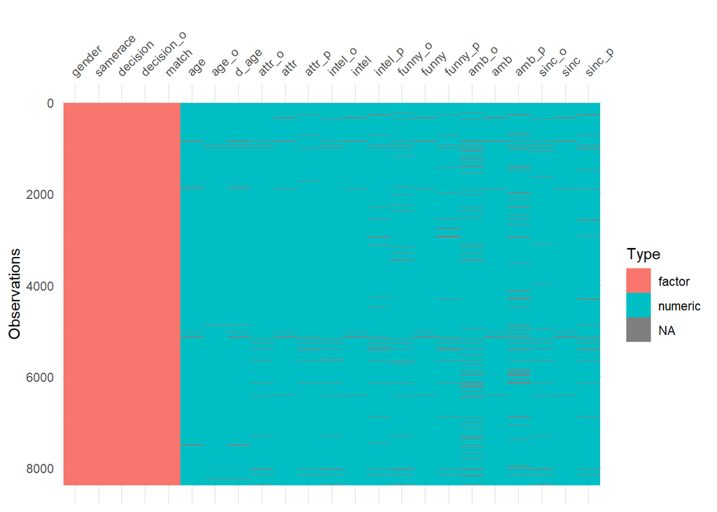

```r
vis_dat(data)
```

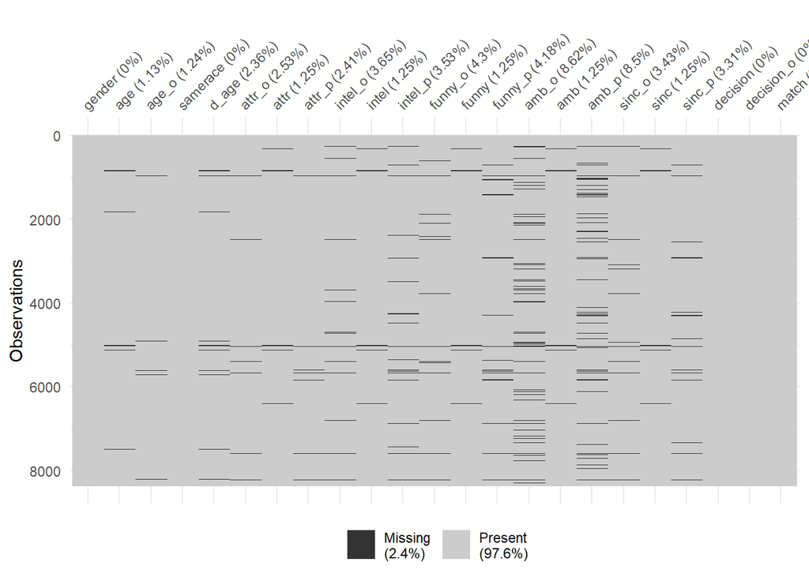

```r
vis_miss(data)
```

Jak widzimy braki danych występują w kolumnach wieku oraz ocen [jakichkolwiek, zarówno swoich i partnera], generalnie we wszystkich liczbowych nie ma całości. Są jednak kompletne informacje w temacie płci, a także decyzji co do chęci na następne spotkanie.

Zweryfikujmy jeszcze liczbę nieodwzajemnionych “polubień” i wszystkich matchy.

```r
likes <- as.integer(data$decision) + as.integer(data$decision_o) - 2
knitr::kable(prop.table(table(likes)))
```

| likes | Freq |
| --- | --- |
| 0 | 0.3252566 |
| 1 | 0.5100263 |
| 2 | 0.1647171 |

No i mamy jeszcze jeden wniosek…

7. Tylko co szósta para jednogłośnie ogłosiła chęć kolejnego spotkania. Co ciekawe **aż połowa werdyktów to nieodwzajemnione polubienia**, a tylko około 1/3 randkowiczów zgodnie stwierdziła, że nie ma co dalej marnować czasu.

Wiemy już na czym stoimy w ogólnym stopniu. Skorzystajmy z narzędzi nauczonych na laboratoriach 2 w celu zdobycia jeszcze większej ilości przydatnych informacji o brakach danych w naszym Speed-datingowym zbiorze.

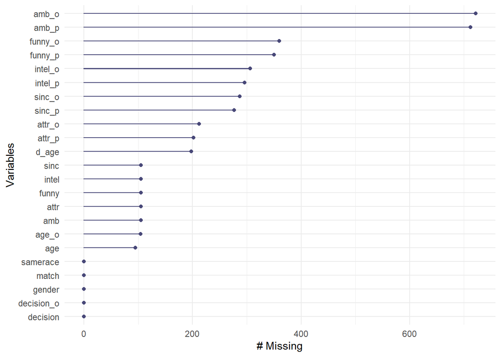

```r
gg_miss_var(data)
```

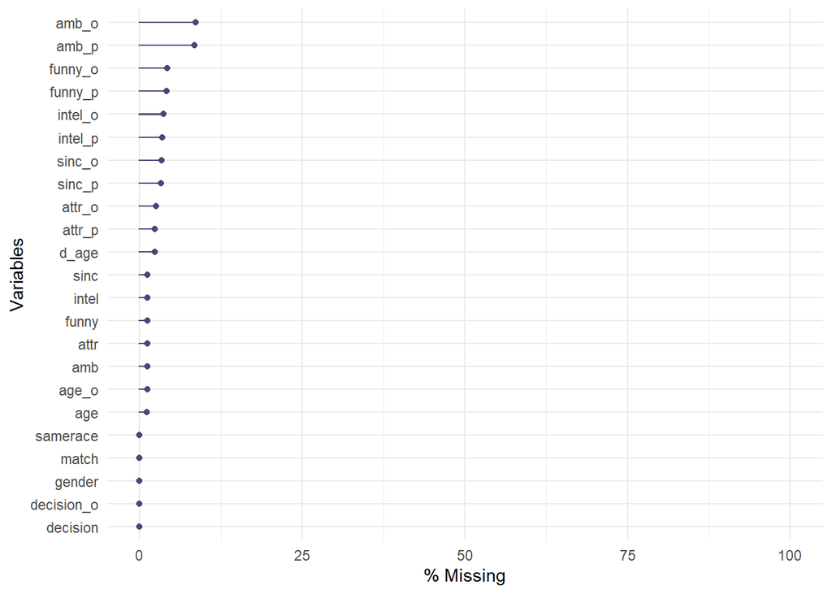

```r
gg_miss_var(data,
            show_pct = TRUE) +
  ylim(0, 100)
```

Tak oto otrzymaliśmy ładną wizualizację ilości braków danych dla kolejnych kolumn. Jak widać niemalże w każdym wypadku jest to maksymalnie kilka procent - jedynym wyjątkiem jest ocena ambicji partnera, której nieobecność sięga prawie 10% wszystkich danych. Czyżbyśmy mogli wstępnie pomyśleć, że olanie wierszy zawierających jakiekolwiek NA lub ich modyfikacja nie powinny wpłynąć bardzo na istotę zbioru?

Ładną prezentację możemy także otrzymać dzięki pakietowi *DataExplorer*.

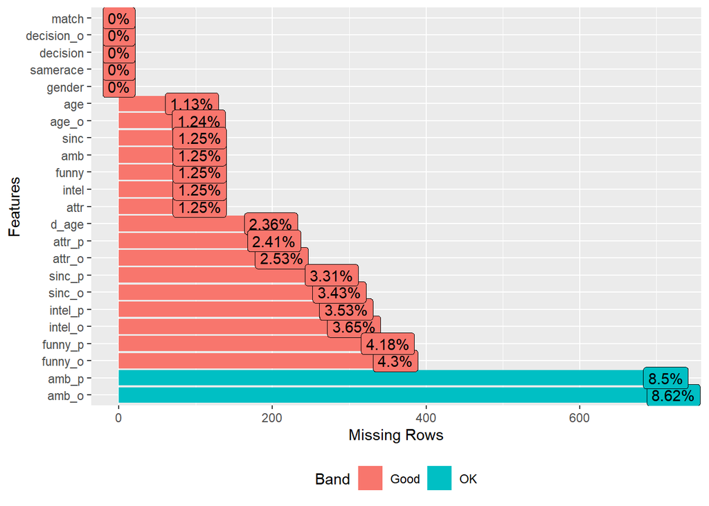

```r
plot_missing(data)
```

Znając konkretne liczby możemy się spodziewać, że dla tak rzadkich braków nie powinniśmy się obawiać dużych rożnic w analizie zależności od tego, co z nimi zrobimy.

# 4. Wizualizacje wybranych zależności i wnioski z różnych sposobów impotacji

## 4.1. Przygotowanie pomocniczych ramek danych.

Zanim rozpoczniemy, przygojmy ramki danych na których będziemy użytkować.

### 4.1.1. no_na_rows - usunięcie wierszy zawierających jakiekolwiek NA

Usuńmy brakujące wartości.

```r
no_na_rows <- na.omit(data)
print(paste("Usunietych wierszy:", nrow(data) - nrow(no_na_rows)))
```

```
## [1] "Usunietych wierszy: 1625"
```

```r
print(paste("Procent usunietych wierszy:", round((nrow(data) - nrow(no_na_rows)) / nrow(data) * 100, 2), "%"))
```

```
## [1] "Procent usunietych wierszy: 19.4 %"
```

Tracimy 1/5 danych - umówmy się, to już jednak trochę jest. No cóż…

### 4.1.2. means - NA zastąpione średnimi

Zastąpmy średnimi.

```r
imp <- mice(data, method = "mean", m = 1, maxit = 1)
```

Wypełnijmy naszą nową ramkę danych.

```r
means <- complete(imp)
```

### 4.1.3. randoms - NA zastąpione losowymi z kolumn

Zastąpmy brakujące wartości losowymi z naszej próbki.

```r
imp2 <- mice(data, method = "sample", m = 1, maxit = 1)
```

Wypełnijmy naszą nową ramkę danych.

```r
randoms <- complete(imp2)
```

```r
means_no_ambs <- means %>%
  select(-c(amb, amb_p))
```

## 4.2. Wizualizacje

### 4.2.1. Ocena potencjalnej drugiej połówki a różnica wieku

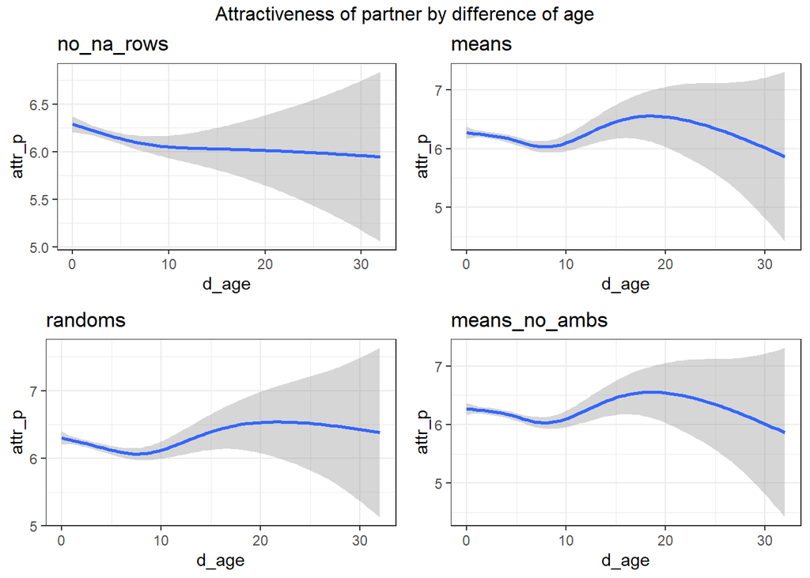

```r
g1 <- ggplot(no_na_rows, aes(x = d_age, y = attr_p)) +
  geom_smooth() +
  ggtitle("no_na_rows") +
  theme_bw()

g2 <- ggplot(means, aes(x = d_age, y = attr_p)) +
  geom_smooth() +
  ggtitle("means") +
  theme_bw()

g3 <- ggplot(randoms, aes(x = d_age, y = attr_p)) +
  geom_smooth() +
  ggtitle("randoms") +
  theme_bw()

g4 <- ggplot(means_no_ambs, aes(x = d_age, y = attr_p)) +
  geom_smooth() +
  ggtitle("means_no_ambs") +
  theme_bw()

grid.arrange(g1, g2, g3, g4, ncol = 2, top = "Attractiveness of partner by difference of age")
```

O proszę! Już dla pierwszej lepszej zależności widzimy duże różnice

Najbardziej chyba odstaje przypadek usunięcia prawie 1/5 wierszy, czyli tam, gdzie pozbyliśmy się tych zawierających jakiekolwiek braki. Tam dane mówią jasno - im większa różnica wieku, tym ocena atrakcyjności gorsza.

### 4.2.2. Cechy partnera a decyzja

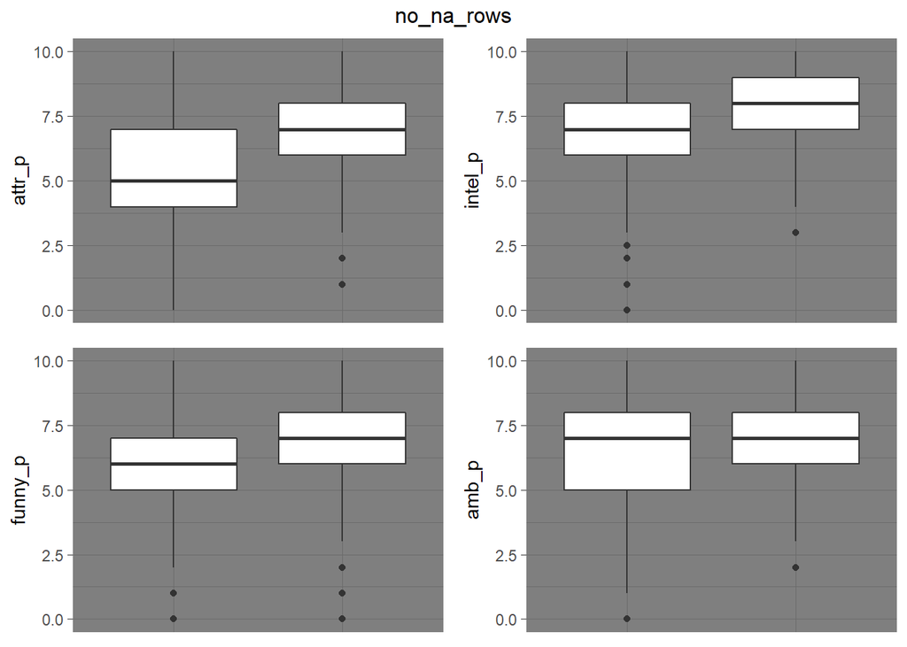

```r
g1_1 <- ggplot(no_na_rows, aes(x = decision, y = attr_p)) +
  geom_boxplot() +
  theme_dark() +
  theme(axis.title.x=element_blank(),
        axis.text.x=element_blank(),
        axis.ticks.x=element_blank())
g1_2 <- ggplot(no_na_rows, aes(x = decision, y = intel_p)) +
  geom_boxplot() +
  theme_dark() +
  theme(axis.title.x=element_blank(),
        axis.text.x=element_blank(),
        axis.ticks.x=element_blank())
g1_3 <- ggplot(no_na_rows, aes(x = decision, y = funny_p)) +
  geom_boxplot() +
  theme_dark() +
  theme(axis.title.x=element_blank(),
        axis.text.x=element_blank(),
        axis.ticks.x=element_blank())
g1_4 <- ggplot(no_na_rows, aes(x = decision, y = amb_p)) +
  geom_boxplot() +
  theme_dark() +
  theme(axis.title.x=element_blank(),
        axis.text.x=element_blank(),
        axis.ticks.x=element_blank())
g1 <- grid.arrange(g1_1, g1_2, g1_3, g1_4, ncol=2, top = "no_na_rows")
```

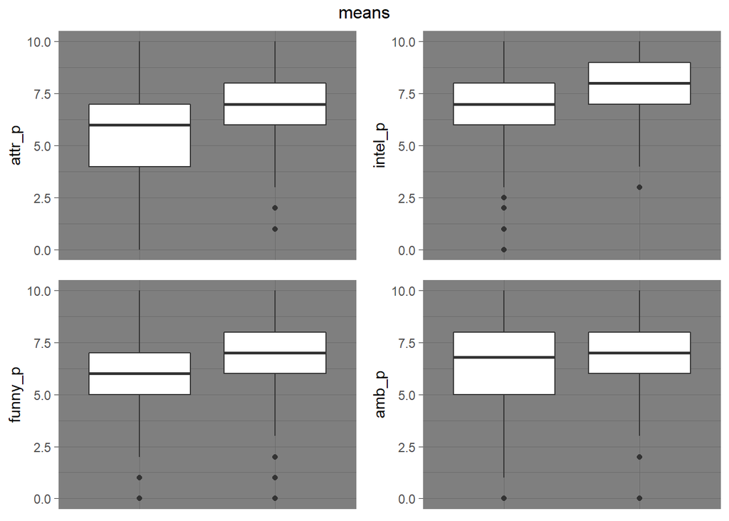

```r
g2_1 <- ggplot(means, aes(x = decision, y = attr_p)) +
  geom_boxplot() +
  theme_dark() +
  theme(axis.title.x=element_blank(),
        axis.text.x=element_blank(),
        axis.ticks.x=element_blank())
g2_2 <- ggplot(means, aes(x = decision, y = intel_p)) +
  geom_boxplot() +
  theme_dark() +
  theme(axis.title.x=element_blank(),
        axis.text.x=element_blank(),
        axis.ticks.x=element_blank())
g2_3 <- ggplot(means, aes(x = decision, y = funny_p)) +
  geom_boxplot() +
  theme_dark() +
  theme(axis.title.x=element_blank(),
        axis.text.x=element_blank(),
        axis.ticks.x=element_blank())
g2_4 <- ggplot(means, aes(x = decision, y = amb_p)) +
  geom_boxplot() +
  theme_dark() +
  theme(axis.title.x=element_blank(),
        axis.text.x=element_blank(),
        axis.ticks.x=element_blank())
g2 <- grid.arrange(g2_1, g2_2, g2_3, g2_4, ncol=2, top = "means")
```

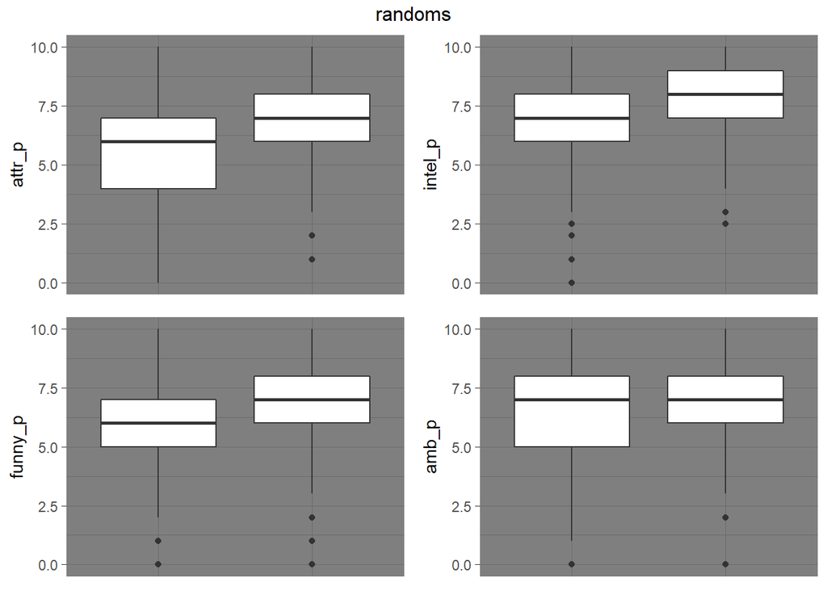

```r
g3_1 <- ggplot(randoms, aes(x = decision, y = attr_p)) +
  geom_boxplot() +
  theme_dark() +
  theme(axis.title.x=element_blank(),
        axis.text.x=element_blank(),
        axis.ticks.x=element_blank())
g3_2 <- ggplot(randoms, aes(x = decision, y = intel_p)) +
  geom_boxplot() +
  theme_dark() +
  theme(axis.title.x=element_blank(),
        axis.text.x=element_blank(),
        axis.ticks.x=element_blank())
g3_3 <- ggplot(randoms, aes(x = decision, y = funny_p)) +
  geom_boxplot() +
  theme_dark() +
  theme(axis.title.x=element_blank(),
        axis.text.x=element_blank(),
        axis.ticks.x=element_blank())
g3_4 <- ggplot(randoms, aes(x = decision, y = amb_p)) +
  geom_boxplot() +
  theme_dark() +
  theme(axis.title.x=element_blank(),
        axis.text.x=element_blank(),
        axis.ticks.x=element_blank())
g3 <- grid.arrange(g3_1, g3_2, g3_3, g3_4, ncol=2, top = "randoms")
```

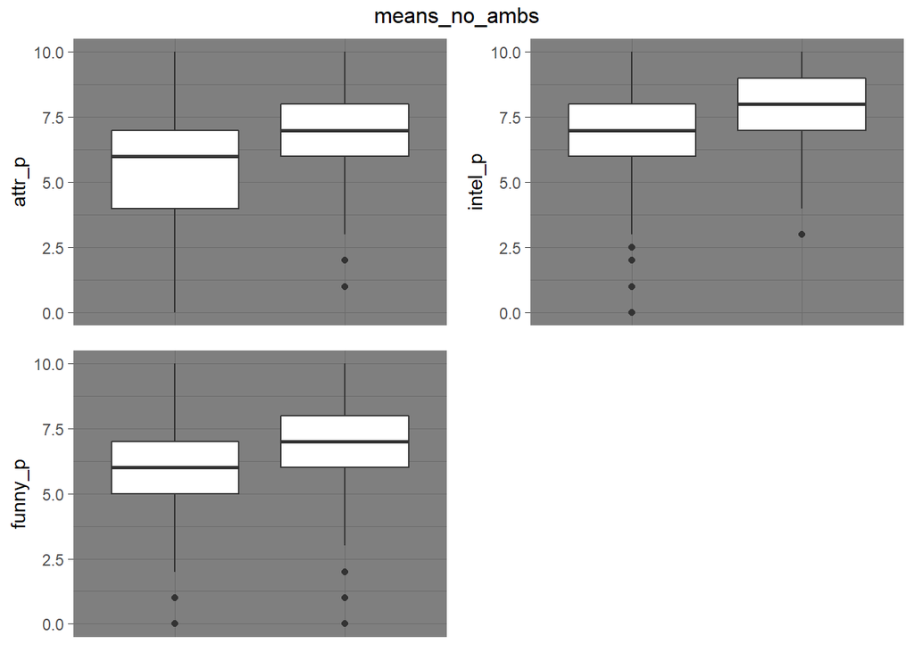

```r
g4_1 <- ggplot(means_no_ambs, aes(x = decision, y = attr_p)) +
  geom_boxplot() +
  theme_dark() +
  theme(axis.title.x=element_blank(),
        axis.text.x=element_blank(),
        axis.ticks.x=element_blank())
g4_2 <- ggplot(means_no_ambs, aes(x = decision, y = intel_p)) +
  geom_boxplot() +
  theme_dark() +
  theme(axis.title.x=element_blank(),
        axis.text.x=element_blank(),
        axis.ticks.x=element_blank())
g4_3 <- ggplot(means_no_ambs, aes(x = decision, y = funny_p)) +
  geom_boxplot() +
  theme_dark() +
  theme(axis.title.x=element_blank(),
        axis.text.x=element_blank(),
        axis.ticks.x=element_blank())
g4 <- grid.arrange(g4_1, g4_2, g4_3, ncol=2, top = "means_no_ambs")
```

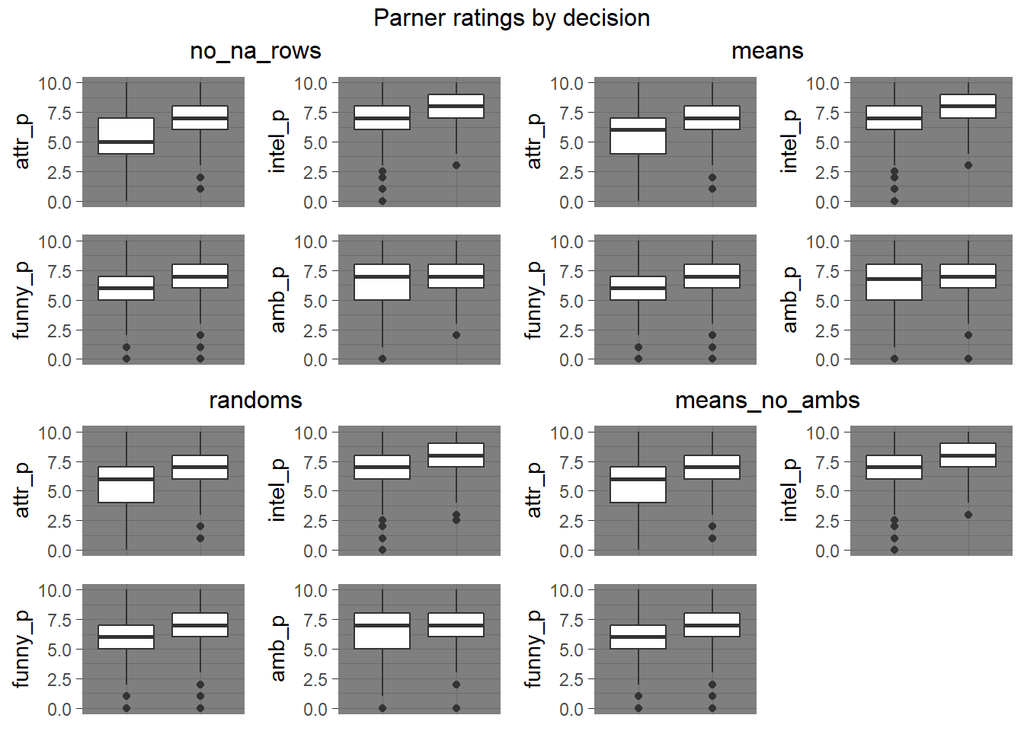

```r
grid.arrange(g1, g2, g3, g4, ncol = 2, top = "Parner ratings by decision")
```

Tutaj niezależnie od zbioru danych efekty są w miarę podobne - najbardziej w oczy rzuca się chyba zejście mediany oceny atrakcyjności partnera niechcianego z 6 do 5 dla ramki z usuniętymi wierszami z NA - czyli chyba można wnioskować, że partner nam się bardziej podoba <-> więcej o nim powiemy.

Co ciekawe, mediana ocen speed-partnerów uznanych za godnych następnego spotkania jest niemalże równa trzeciemu kwantylowi niewybranych. Dotyczy to zarówno inteligencji, atrakcyjności jak i poczucia humoru [wyjątek stanowi ocena ambicji]. Co ciekawe, uczestnicy zdecydowanie lepiej ocenili inteligencję niż atrakcyjność swoich randkowiczów - wykresy skrzynkowe inteligencji niewybranych partnerów są niemalże identyczne jak boxploty wybranych biorąc pod uwagę atrakcyjność.

### 4.2.3. Różnica wieku i płeć a matche

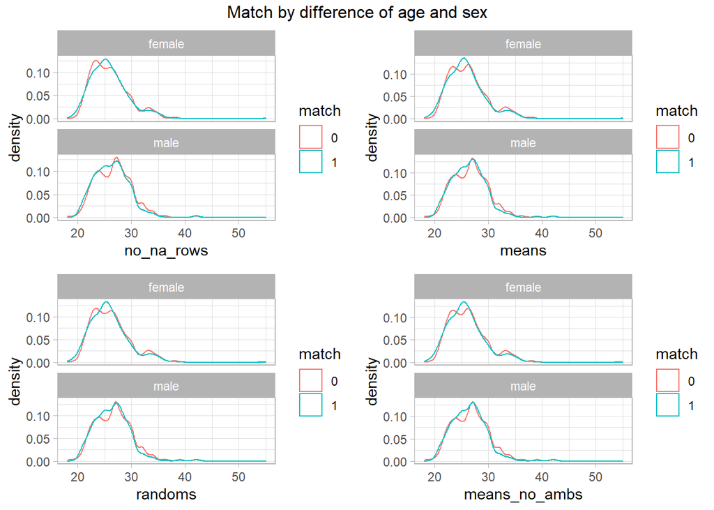

```r
g1 <- ggplot(no_na_rows, aes(x = age, color = match)) +
  geom_density() +
  facet_wrap(~gender, ncol = 1) +
  xlab("no_na_rows") +
  theme_light()

g2 <- ggplot(means, aes(x = age, color = match)) +
  geom_density() +
  facet_wrap(~gender, ncol = 1) +
  xlab("means") +
  theme_light()

g3 <- ggplot(randoms, aes(x = age, color = match)) +
  geom_density() +
  facet_wrap(~gender, ncol = 1) +
  xlab("randoms") +
  theme_light()

g4 <- ggplot(means_no_ambs, aes(x = age, color = match)) +
  geom_density() +
  facet_wrap(~gender, ncol = 1) +
  xlab("means_no_ambs") +
  theme_light()

grid.arrange(g1, g2, g3, g4, ncol = 2, top = "Match by difference of age and sex")
```

## 4.3. Wnioski z wykresów

Ze względu na małą liczbę braków danych zastąpienie ich średnimi nie wpłynęło istotnie na wynik naszej analizy i wniosków z niej płynących. Można więc strzelać, że parę procent braków na każdą kolumnę to w praktyce żadna strata.

Zastąpienie brakujących danych losowymi wartościami poskutkowało jeszcze bardziej zbliżonymi wykresami gęstości niż zastępowanie ich średnimi. Niby z matematycznego punktu widzenia ma to sens (patrz: Prawa Wielkich Liczb) i zbiorcze wyniki dla całej populacji często dla takiej modyfikacji zapewne są bardziej zbliżone do rzeczywistości niż uśredniane, takie dane można wyrzucić do kosza patrząc na jednostki - konkretnym Jankom i Aniom przypisujemy informacje zupełnie bez ładu i składu, tożto nonsens.

Generalnie trudno jednoznacznie stwierdzić która imputacja jest lepsza, a która gorsza - to już nam chyba pokaże algorytm uczenia maszynowego i weryfikacja jego efektu na tych czterech ramkach.

Biorąc pod uwagę małą liczbę braków, niezależnie od usunięcia wierszy zawierających wartości NA, zastępowanie brakujących wartości średnimi czy zamienianie ich na losowe z odpowiadajej jej kolumny, nie wpłynęło na ogólną analizę danych jako na zbiorczy twór - przynajmniej na pierwszy rzut oka. Można wysnuć wniosek, że zastępowanie liczbami losowymi globalnie daje efekt bardziej zbliżony do rzeczywistości, lecz zamienianie na średnie mniej burzy obraz jednostek.

## 4.4. Porównanie macierzy korelacji

Mamy takie super narzędzie, to i z niego skorzystajmy.

[figure not shown]

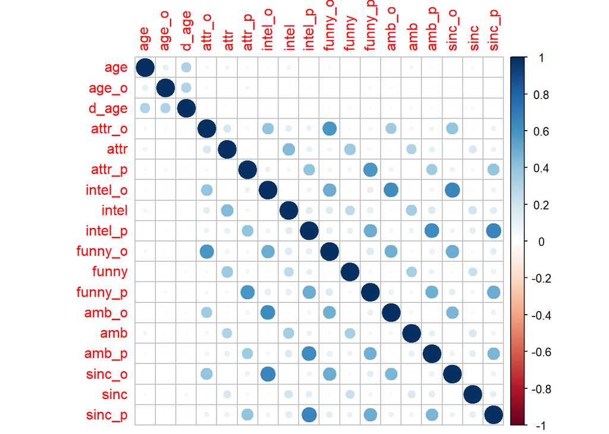

```r
# install.packages("corrplot") # if not installed
library(corrplot)
# install.packages("corrgram") # if not installed
library(corrgram)
corrplot(corrgram(data), method="circle")
```

[figure not shown]

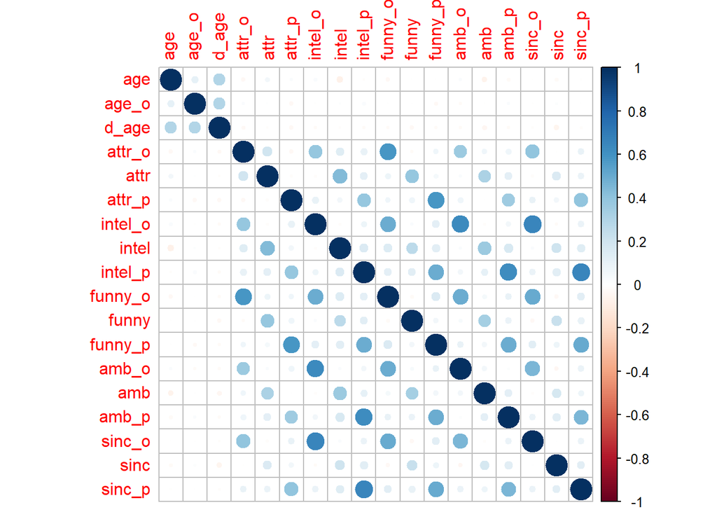

```r
corrplot(corrgram(no_na_rows), method="circle")
```

[figure not shown]

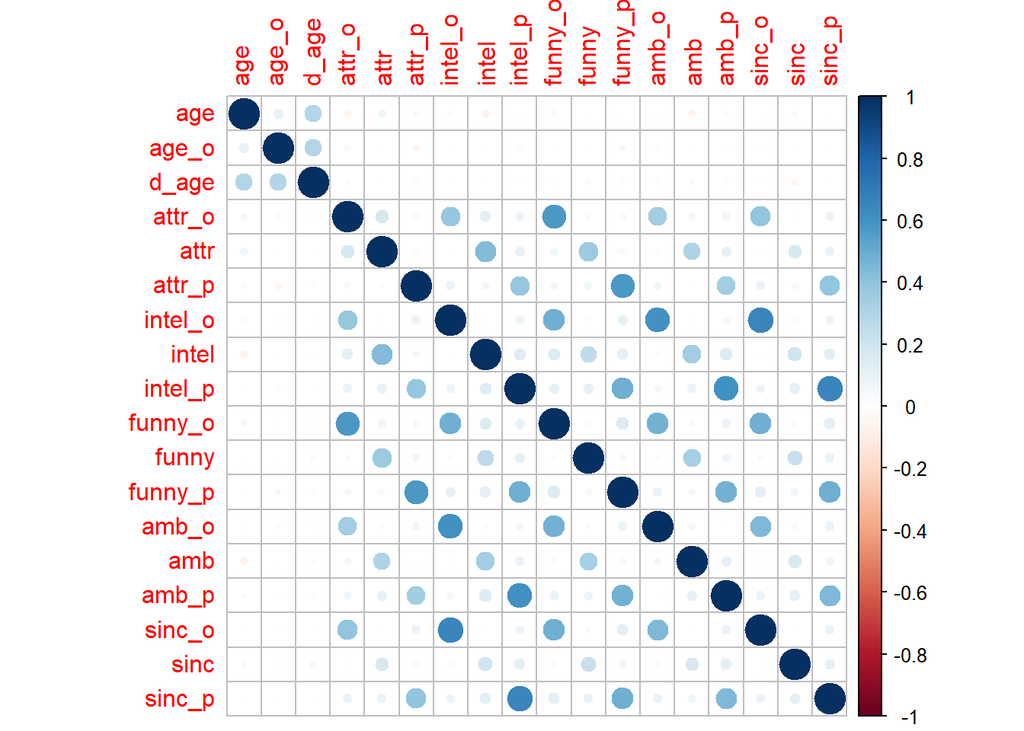

```r
corrplot(corrgram(means), method="circle")
```

[figure not shown]

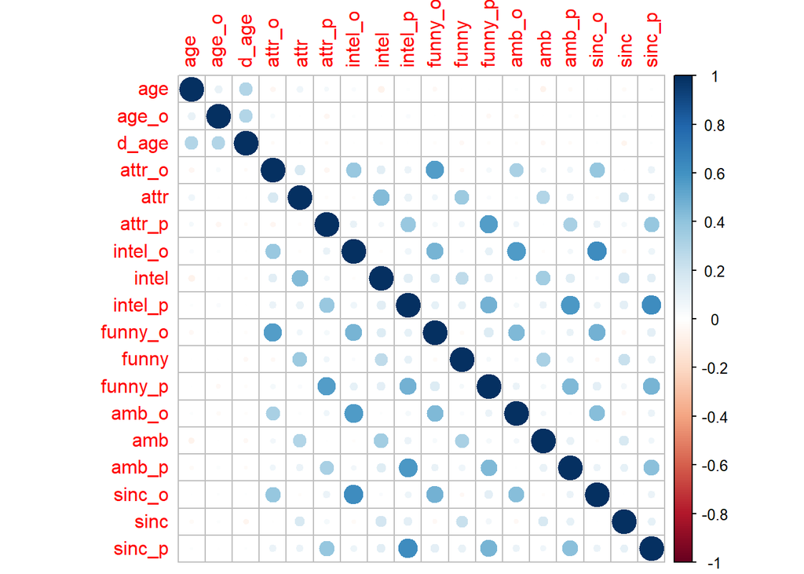

```r
corrplot(corrgram(randoms), method="circle")
```

[figure not shown]

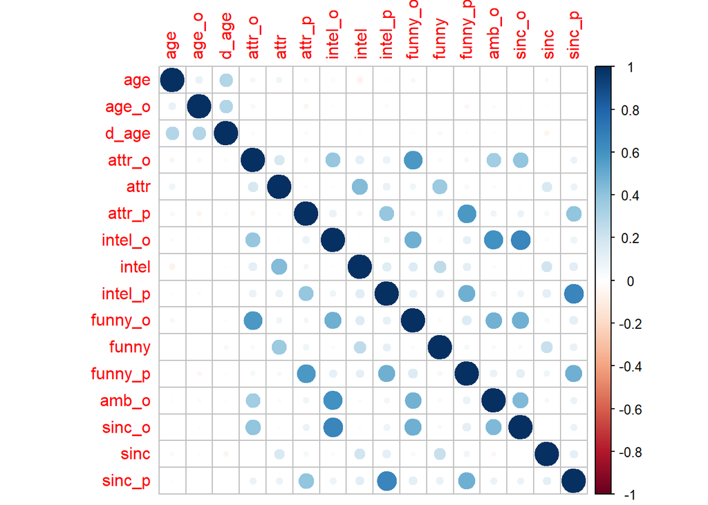

```r
corrplot(corrgram(means_no_ambs), method="circle")
```

Wykresy korelacji są do siebie w miarę zbliżone - kolejny sygnał predykujący, że dla tak małej ilości braków danych sposób ich wypełnienia nie powinien robić ogromnej różnicy.

# 5. Algorytm uczenia maszynowego

## 5.1. Wprowadzenie

Zbiorami danych, na których wytrenujemy nasz algorytm będą te utworzone w poprzednim rozdziale:

Klasą niech będzie *match* a cechami - wszystkie kolumny za wyjątkiem *decision* i *decision_o* - wszystkie składają się na to co myślimy o partnerze lub jak on nas postrzega, tylko jedynie te dwie ostatnia są złożeniem naszej klasy.

Oczywiście można by także dokonać ciekawej klasyfikacji trenując nasz algorytm pod prognozowanie *decision* lub *decision_o* - zdecydowałem się jednak na *match*, ponieważ to on odpowiada za finalny efekt i najważniejszy wynik randki, a przy tym na swój sposób ma “pod sobą” dwa wspomniane.

Mamy tutaj styczność z typową **klasyfikacją binarną**.

```r
colnames(data)
```

```
##  [1] "gender"     "age"        "age_o"      "samerace"   "d_age"
##  [6] "attr_o"     "attr"       "attr_p"     "intel_o"    "intel"
## [11] "intel_p"    "funny_o"    "funny"      "funny_p"    "amb_o"
## [16] "amb"        "amb_p"      "sinc_o"     "sinc"       "sinc_p"
## [21] "decision"   "decision_o" "match"
```

```r
cechy <- colnames(data)[1:20]
klasa <- colnames(data)[23]
cechy_no_ambs <- colnames(means_no_ambs)[1:18]
klasa_no_ambs <- colnames(means_no_ambs)[21]

p <- length(cechy)
n_no <- nrow(no_na_rows) # liczba wierszy w wariancie usuwania tych z NA
n <- nrow(means) # liczba wierwszy w wariancie zastępowania brakujących
```

## 5.2. Podział na zbiór testowy i treningowy

Zrobię to w chyba najbardziej standardowy sposób - losowe 20% idzie na zbiór testowy, a pozostałe - na treningowy.

```r
set.seed(123)

id_train_n <- sample(1:n, 4/5 * n)
id_train_n_no <- sample(1:n_no, 4/5 * n_no)

train_no_rows <- no_na_rows[id_train_n_no, c(cechy, klasa)]
train_means <- means[id_train_n, c(cechy, klasa)]
train_samples <- randoms[id_train_n, c(cechy, klasa)]
train_means_no_ambs <- means_no_ambs[id_train_n, c(cechy_no_ambs, klasa_no_ambs)]

id_test_n <- (1:n)[-id_train_n]
id_test_n_no <- (1:n_no)[-id_train_n_no]

test_no_rows <- no_na_rows[id_test_n_no, c(cechy, klasa)]
test_means <- means[id_test_n, c(cechy, klasa)]
test_samples <- randoms[id_test_n, c(cechy, klasa)]
test_means_no_ambs <- means_no_ambs[id_test_n, c(cechy_no_ambs, klasa_no_ambs)]
```

Dzięki takim samym wylosowanym indeksowym treningowym, będziemy mogli porównać wyniki dla *means*, *samples* i *means_no_ambs* dla tych samych wierszy. Operacja będzie niestety niemożliwa dla *no_na_rows* ze względu na inną wielkość analizowanych wartości.

## 5.3. Klasyfikacja z pomocą drzewa klasyfikacyjnego

No nie powiem, urzekły mnie te wesołe binarne cosie z labów trzecich.

### 5.3.1. Usunięte wiersze z NA

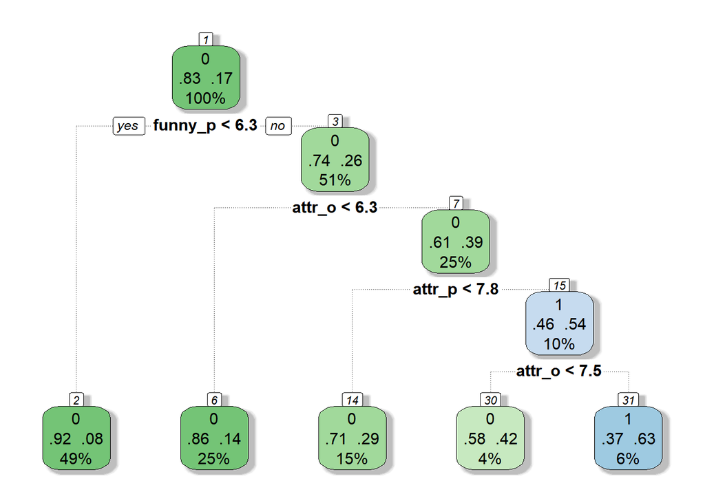

```r
# install.packages("rpart") # if not installed
library(rpart)
tree_classifier_no_rows <- rpart(match~., data = train_no_rows)
par(mar = c(1,1,1,1))
par(xpd = TRUE)

# install.packages("rattle") # if not installed
library(rattle)
fancyRpartPlot(tree_classifier_no_rows, caption = NULL)
```

```r
predict(tree_classifier_no_rows, newdata = test_no_rows[,cechy], type="class")[1:20]
```

```
##   4  21  23  28  36  40  48  53  61  68  70  81  87  94  98  99 100 105
##   0   0   0   0   0   0   0   0   0   0   0   1   0   0   0   0   0   0
## 110 113
##   0   0
## Levels: 0 1
```

```r
predict(tree_classifier_no_rows, newdata = test_no_rows[,cechy], type="prob")[1:20]
```

```
##  [1] 0.7104623 0.8638360 0.5752212 0.5752212 0.7104623 0.9241742 0.8638360
##  [8] 0.8638360 0.9241742 0.7104623 0.9241742 0.3734568 0.7104623 0.8638360
## [15] 0.5752212 0.8638360 0.8638360 0.8638360 0.7104623 0.9241742
```

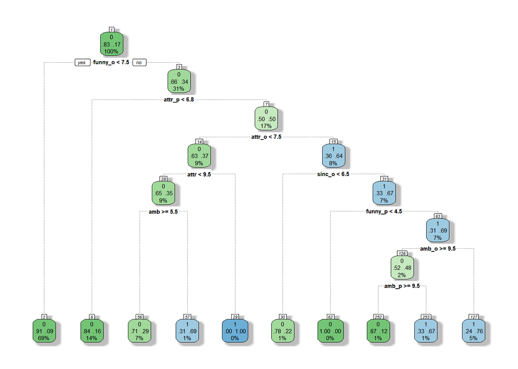

```r
tree_classifier_parameter_change_no_na <- rpart(match~., data=test_no_rows,
  parms = list(split = 'information'),
  minsplit = 10,
  cp = 0.01)
fancyRpartPlot(tree_classifier_parameter_change_no_na, caption = NULL)
```

O proszę! Wychodzi na to, że algorytm stwierdził, że to jednak atrakcyjność ma kluczową wartość - z góry odrzucamy wszystkich tych poniżej 7 / 10. Samemu powinniśmy też zostać ocenieni na +8 / 10 w temacie poczucia humoru, w innym wypadku out.

### 5.3.2. NA uzupełnione średnimi

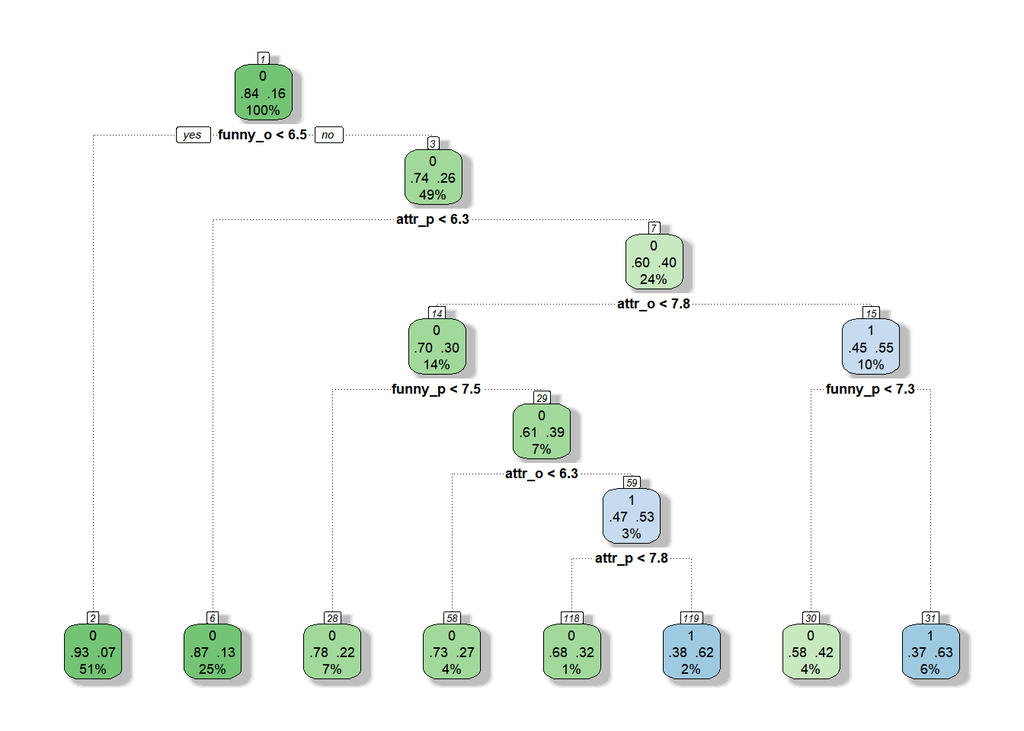

```r
tree_classifier_means <- rpart(match~., data = train_means)
par(mar = c(1,1,1,1))
par(xpd = TRUE)

fancyRpartPlot(tree_classifier_means, caption = NULL)
```

```r
predict(tree_classifier_means, newdata = test_means[,cechy], type = "class")[1:20]
```

```
##  8 10 12 14 19 24 29 33 34 37 40 43 46 47 48 50 69 70 74 80
##  0  0  0  0  1  0  1  0  1  0  1  0  0  0  0  0  0  0  0  0
## Levels: 0 1
```

```r
predict(tree_classifier_means, newdata = test_means[,cechy], type = "prob")[1:20]
```

```
##  [1] 0.9311967 0.9311967 0.9311967 0.5785441 0.3697917 0.7819706 0.3806452
##  [8] 0.8693853 0.3806452 0.9311967 0.3806452 0.8693853 0.8693853 0.9311967
## [15] 0.9311967 0.7286245 0.8693853 0.9311967 0.5785441 0.5785441
```

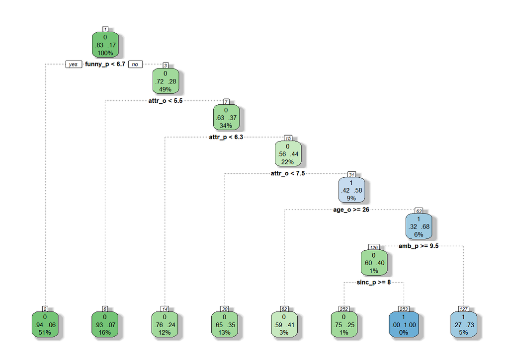

```r
tree_classifier_parameter_change_means <- rpart(match~., data=test_means,
  parms = list(split = 'information'),
  minsplit = 10,
  cp = 0.01)
fancyRpartPlot(tree_classifier_parameter_change_means, caption = NULL)
```

Interesujące jak tutaj pod uwagę zaczął być brany wiek partnera i przynajmniej w minimalnym stopniu ocena jego szczerości (w rzadkich przypadkach).

W ten model prędzej uwierzę!

### 5.3.3. NA uzupełnione losowymi

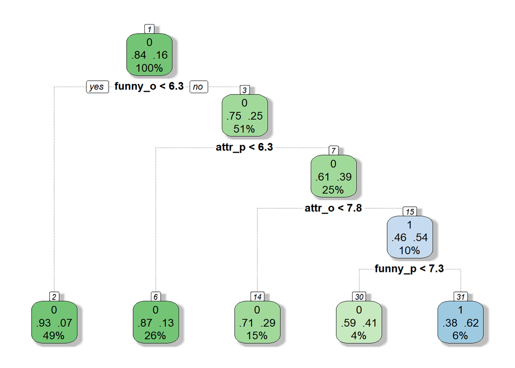

```r
tree_classifier_samples <- rpart(match~., data = train_samples)
par(mar = c(1,1,1,1))
par(xpd = TRUE)

fancyRpartPlot(tree_classifier_samples, caption = NULL)
```

```r
predict(tree_classifier_samples, newdata = test_samples[,cechy], type = "class")[1:20]
```

```
##  8 10 12 14 19 24 29 33 34 37 40 43 46 47 48 50 69 70 74 80
##  0  0  0  0  1  0  0  0  0  0  0  0  0  0  0  0  0  0  0  0
## Levels: 0 1
```

```r
predict(tree_classifier_samples, newdata = test_samples[,cechy], type = "prob")[1:20]
```

```
##  [1] 0.9299908 0.9299908 0.9299908 0.5873606 0.3801020 0.7082097 0.7082097
##  [8] 0.8737919 0.7082097 0.9299908 0.7082097 0.8737919 0.8737919 0.9299908
## [15] 0.9299908 0.7082097 0.8737919 0.9299908 0.5873606 0.5873606
```

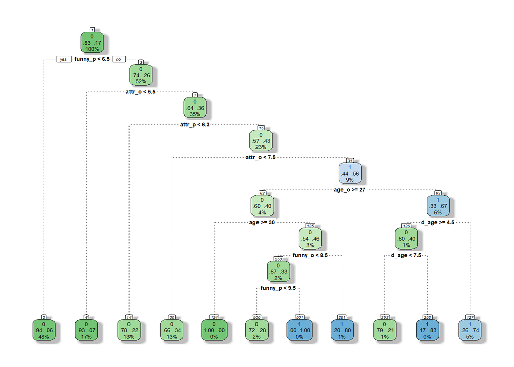

```r
tree_classifier_parameter_change_samples <- rpart(match~., data=test_samples,
  parms = list(split = 'information'),
  minsplit = 10,
  cp = 0.01)
fancyRpartPlot(tree_classifier_parameter_change_samples, caption = NULL)
```

Kolejne niebanalne drzewko z poczuciem humoru i zabawnością na czele a także z elementami istotności wieku.

Co musi zostać spełnione?

1. Twoja atrakcyjność oceniona +8 / 10,
2. Zabawność partnera +7 / 10,
3. Jego atrakcyjność +7 / 10.

Ciekawe i nie głupie.

### 5.3.4. NA uzupełnione średnimi z usuniętymi kolumnami o brakach >5%

```r
tree_classifier_means_no_ambs <- rpart(match~., data = train_means_no_ambs)
par(mar = c(1,1,1,1))
par(xpd = TRUE)

fancyRpartPlot(tree_classifier_means_no_ambs, caption = NULL)

predict(tree_classifier_means_no_ambs, newdata = test_means_no_ambs[,cechy_no_ambs], type = "class")[1:20]
```

[output not shown]

```
##  8 10 12 14 19 24 29 33 34 37 40 43 46 47 48 50 69 70 74 80
##  0  0  0  0  1  0  1  0  1  0  1  0  0  0  0  0  0  0  0  0
## Levels: 0 1
```

```r
predict(tree_classifier_means_no_ambs, newdata = test_means_no_ambs[,cechy_no_ambs], type = "prob")[1:20]
```

```
##  [1] 0.9311967 0.9311967 0.9311967 0.5785441 0.3697917 0.7819706 0.3806452
##  [8] 0.8693853 0.3806452 0.9311967 0.3806452 0.8693853 0.8693853 0.9311967
## [15] 0.9311967 0.7286245 0.8693853 0.9311967 0.5785441 0.5785441
```

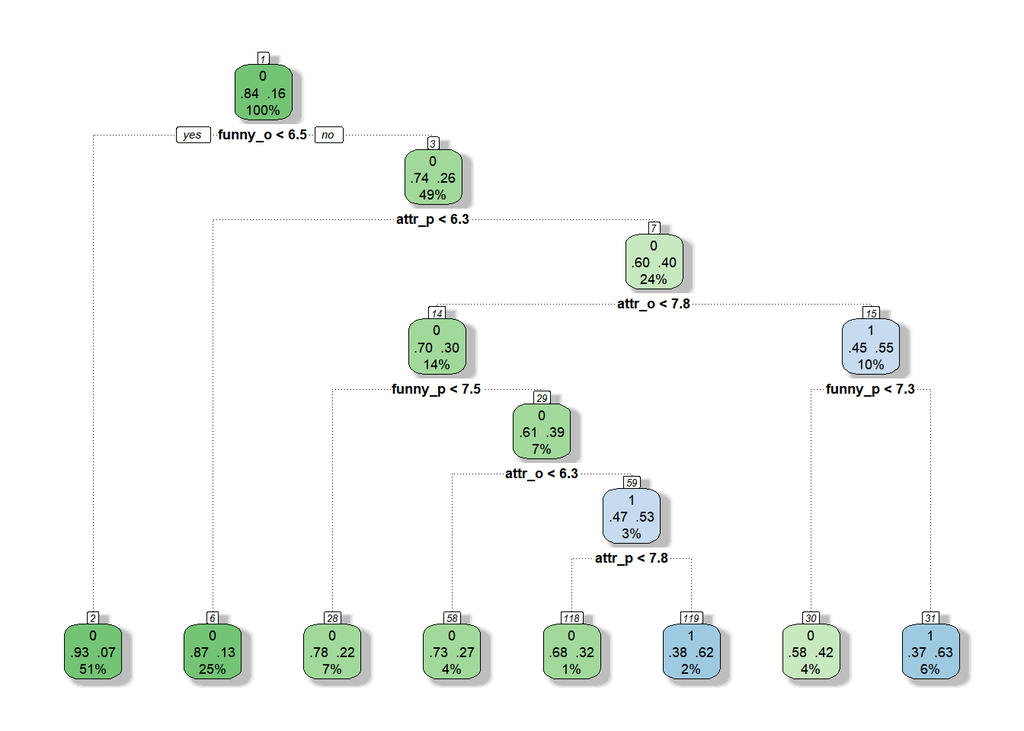

```r
tree_classifier_parameter_change_samples <- rpart(match~., data=test_means_no_ambs,
  parms = list(split = 'information'),
  minsplit = 10,
  cp = 0.01)
fancyRpartPlot(tree_classifier_means_no_ambs, caption = NULL)
```

Atrakcyjność i poczucie humoru - tyle w temacie.

## 5.4. Porównanie modeli predykcyjnych

Kluczowe dla oceny według drzew klasyfikacyjnych są atrakcyjność i poczucie humoru, rzadziej wiek, szczerość czy ambicje. **Rasa w żadnym momencie nie zadecydowała**.

A teraz chwila prawdy - zobaczmy jakiemu procentowi par na podstawie ich danych i atrybutów sztuczna inteligencja dobrze przewidzi wspólną przyszłość [przynajmniej niedaleką].

```r
tree_classifier_test_prediction_class_no_rows <- predict(tree_classifier_no_rows, newdata = test_no_rows, type = 'class')

type_of_error <- ifelse(test_no_rows$match=='0' & tree_classifier_test_prediction_class_no_rows == '0', "TN",
                      ifelse(test_no_rows$match=='0' & tree_classifier_test_prediction_class_no_rows=='1', "FP",
                       ifelse(test_no_rows$match=='1' & tree_classifier_test_prediction_class_no_rows=='0', "FN", "TP")))

(conf.val <- table(type_of_error))
```

```
## type_of_error
##   FN   FP   TN   TP
##  178   33 1090   50
```

```r
accuracy_no_na <- (conf.val['TP']+conf.val['TN'])/sum(conf.val)
print(paste0("Skutecznosc dla usunietych wierszy z NA: ", accuracy_no_na))
```

```
## [1] "Skutecznosc dla usunietych wierszy z NA: 0.843819393042191"
```

```r
tree_classifier_test_prediction_class_means <- predict(tree_classifier_means, newdata = test_means, type = 'class')

type_of_error <- ifelse(test_means$match=='0' & tree_classifier_test_prediction_class_means == '0', "TN",
                      ifelse(test_means$match=='0' & tree_classifier_test_prediction_class_means=='1', "FP",
                       ifelse(test_means$match=='1' & tree_classifier_test_prediction_class_means=='0', "FN", "TP")))

(conf.val <- table(type_of_error))
```

```
## type_of_error
##   FN   FP   TN   TP
##  211   59 1337   69
```

```r
accuracy_means <- (conf.val['TP']+conf.val['TN'])/sum(conf.val)
print(paste0("Skutecznosc dla NA zastapionych srednimi: ", accuracy_means))
```

```
## [1] "Skutecznosc dla NA zastapionych srednimi: 0.83890214797136"
```

```r
tree_classifier_test_prediction_class_samples <- predict(tree_classifier_samples, newdata = test_samples, type = 'class')

type_of_error <- ifelse(test_samples$match=='0' & tree_classifier_test_prediction_class_samples == '0', "TN",
                      ifelse(test_samples$match=='0' & tree_classifier_test_prediction_class_samples=='1', "FP",
                       ifelse(test_samples$match=='1' & tree_classifier_test_prediction_class_samples=='0', "FN", "TP")))

(conf.val <- table(type_of_error))
```

```
## type_of_error
##   FN   FP   TN   TP
##  220   39 1357   60
```

```r
accuracy_samples <- (conf.val['TP']+conf.val['TN'])/sum(conf.val)
print(paste0("Skutecznosc dla NA zastapionych losowymi: ", accuracy_samples))
```

```
## [1] "Skutecznosc dla NA zastapionych losowymi: 0.845465393794749"
```

```r
tree_classifier_test_prediction_class_means_no_ambs <- predict(tree_classifier_means_no_ambs, newdata = test_means_no_ambs, type = 'class')

type_of_error <- ifelse(test_means_no_ambs$match=='0' & tree_classifier_test_prediction_class_means_no_ambs == '0', "TN",
                      ifelse(test_means_no_ambs$match=='0' & tree_classifier_test_prediction_class_means_no_ambs=='1', "FP",
                       ifelse(test_means_no_ambs$match=='1' & tree_classifier_test_prediction_class_means_no_ambs=='0', "FN", "TP")))

(conf.val <- table(type_of_error))
```

```
## type_of_error
##   FN   FP   TN   TP
##  211   59 1337   69
```

```r
accuracy_means_no_ambs <- (conf.val['TP']+conf.val['TN'])/sum(conf.val)
print(paste0("Skutecznosc dla NA zastapianymi srednimi i usunietymi kolumnami o NA >5%: ", accuracy_means_no_ambs))
```

```
## [1] "Skutecznosc dla NA zastapianymi srednimi i usunietymi kolumnami o NA >5%: 0.83890214797136"
```